# week07_in_class

## Project 2 observations:

- project 2 (for some of you) was run up to only 100 points. Try to push python a little
- Intro: it cannot just be a rewrite of the course webpage.
- If you used the snail function that I provided you, you should add comments to it
- Copying code from online is not ok.

Efficient way to implement `primedec(n)`

```python
def primedec(n):
    primelist=myprimes(n)
    factorlist=[]
    for k in primelist:
        while n%k==0:
            factorlist.append(k)
            n=n/k
        if n==1:
            break
    return factorlist
```

Write code that creates a plot of the function $$f(x) = \tan x \qquad \text{for } 0 \leq x \leq \pi$$ Use at least 1000 points

```python
import numpy as np
import matplotlib.pyplot as plt
```

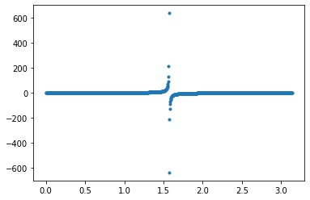

```python
x = np.linspace(0,np.pi,1000)
y = np.tan(x)
plt.plot(x,y,'.')
plt.show()
```

```python
#plt.subplot(3,3,1)
plt.subplot(3,3,7);
```

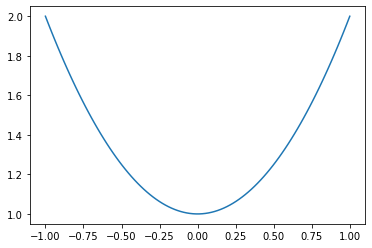

```python
x = np.linspace(-1,1,100)
y = x**2 +1
plt.plot(x,y)
plt.show()
```

## Notes on project 3

- `newton` should implement one step of Newton's method, not including the convergence check

`newton(x0,f,fp)` -> `x1`

### Part 2

- define a function called `find_roots(order,npoints,domain,f,fp,niter,tol)`
- define the roots (maybe in a list)
- define the array with the initial conditions (`meshgrid`)
  - generate real `linpsace`
  - generate the complex `linspace`
  - use `meshgrid` to generate the `xx`,`yy` components of the grid
  - add `xx` and `yy` to generate the full grid
- run Newton's method for `niter` iterations
- create an array called `ccode`
- classify (color code) each point:
  - for each root check what points are close to it -> (color code it with 1,2, or 3) (`x` is close to `r1` if `np.abs(x-r1)<tolerance=0.01`)
  - we assign the root number to a 'matrix' (2d array)
- we return the 2d array

`imshow` the array

## Boolean indexes

```python
a=np.arange(0,12).reshape(3,-1)
a
```

```
array([[ 0,  1,  2,  3],
       [ 4,  5,  6,  7],
       [ 8,  9, 10, 11]])
```

`b` is a `boolean` array

```python
b = a%2==0
b
```

```
array([[ True, False,  True, False],
       [ True, False,  True, False],
       [ True, False,  True, False]])
```

```python
a[b]
```

```
array([ 0,  2,  4,  6,  8, 10])
```

```python
a[b]=700

a
```

```
array([[700,   1, 700,   3],
       [700,   5, 700,   7],
       [700,   9, 700,  11]])
```

```python
a=np.arange(0,12).reshape(3,4)
b= (a%2 == 0)
c=np.zeros((3,4))
print(a,'\n',b,'\n',c)
```

```
[[ 0  1  2  3]
 [ 4  5  6  7]
 [ 8  9 10 11]]
 [[ True False  True False]
 [ True False  True False]
 [ True False  True False]]
 [[0. 0. 0. 0.]
 [0. 0. 0. 0.]
 [0. 0. 0. 0.]]
```

```python
c[b]=-3
c
```

```
array([[-3.,  0., -3.,  0.],
       [-3.,  0., -3.,  0.],
       [-3.,  0., -3.,  0.]])
```

```python
a
```

```
array([[ 0,  1,  2,  3],
       [ 4,  5,  6,  7],
       [ 8,  9, 10, 11]])
```

Combine boolean arrays `&` (and), `|` (or) , `~` (not)

```python
a[(a%2==0) & (a>3)]
```

```
array([ 4,  6,  8, 10])
```

```python
a[(a%2==0) | (a>3)]
```

```
array([ 0,  2,  4,  5,  6,  7,  8,  9, 10, 11])
```

```python
a[(a%2==0) | ~(a>3)]
```

```
array([ 0,  1,  2,  3,  4,  6,  8, 10])
```

```python
c[(a%2==0) & (a>3)]
```

```
array([-3., -3., -3., -3.])
```

**Create an array `c` that has a value of 1 of a where `a` is even, and a value of 7 where `a` is odd**

```python
a = np.arange(12).reshape(4,3)
c=np.zeros((4,3))
a,c
```

```
(array([[ 0,  1,  2],
        [ 3,  4,  5],
        [ 6,  7,  8],
        [ 9, 10, 11]]),
 array([[0., 0., 0.],
        [0., 0., 0.],
        [0., 0., 0.],
        [0., 0., 0.]]))
```

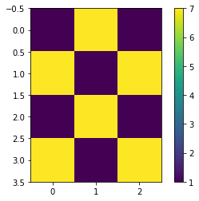

```python
bol = a%2==0
c[bol] = 1
c[a%2==1] = 7
plt.imshow(c)
plt.colorbar()
```

Within `find_roots`

`r1` complex root 1

`z` is the 2d array with the 100th newton iteration

How to check for all the values of `z` close to `r1` ?

`np.abs(z-r1) <tol`

```python
r = np.random.rand(3,4)
i = np.random.rand(3,4)
z = r + complex(0,1)*i
z # fake grid
```

```
array([[0.21735847+0.30447323j, 0.23496291+0.83780495j,
        0.25133291+0.52332107j, 0.5313657 +0.94453727j],
       [0.06383454+0.6171958j , 0.94763477+0.65202995j,
        0.35148024+0.18271675j, 0.49087168+0.50089077j],
       [0.47716473+0.04946187j, 0.94238896+0.80824027j,
        0.44320021+0.57949761j, 0.25714007+0.94794447j]])
```

```python
np.abs(z)
```

[output not shown]

```python
r1 = complex(0.21,0.3)
r1
```

```
(0.21+0.3j)
```

```python
np.abs(z-r1) < 0.01
```

```
array([[ True, False, False, False],
       [False, False, False, False],
       [False, False, False, False]])
```

```python
z=np.random.randint(0,4,(10,10))
z
```

```
array([[0, 1, 0, 1, 1, 0, 3, 1, 0, 3],
       [2, 1, 3, 3, 0, 1, 0, 0, 1, 1],
       [0, 1, 3, 2, 0, 2, 3, 1, 3, 2],
       [0, 1, 0, 2, 0, 0, 1, 3, 2, 3],
       [2, 3, 1, 1, 3, 3, 3, 1, 2, 1],
       [3, 3, 0, 0, 1, 3, 0, 3, 1, 1],
       [3, 1, 2, 3, 1, 1, 3, 1, 2, 2],
       [3, 0, 0, 0, 2, 3, 0, 1, 2, 1],
       [1, 3, 0, 3, 1, 3, 1, 1, 2, 0],
       [0, 0, 3, 3, 1, 2, 3, 2, 0, 1]])
```

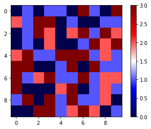

```python
plt.imshow(z,cmap='seismic');
plt.colorbar()
```

## PArt 4

after each Newton's iteration, we should check for convergence: checking for all points that:

- $|x_{k+1}-x_k|<tol$
- have not converged yet
- store the iteration number into an array

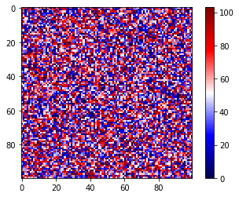

```python
z=np.random.randint(0,104,(100,100))
plt.imshow(z,cmap='seismic');
plt.colorbar()
```

```python
def f(x):
    return x**2
```

```python
def pippo(x,g):
    gx = g(x)
    return gx
```

```python
pippo(17,f)
```

```
289
```

```python
a=2
b=3
```

```python
f(b)
```

```
9
```

```python
def h(x,y=3):
    return x*y
```

```python
pippo(17,h)
```

```
51
```

```python
pippo(17,np.sin)
```

```
-0.9613974918795568
```

```python
pippo(np.array([1,2,3]),f)
```

```
array([1, 4, 9], dtype=int32)
```

# Define roots of polynomial $z^3-1=0$

```python
n=3 # order of polynomial
roots = [complex( np.cos(2*np.pi*k/n), np.sin(2*np.pi*k/n) ) for k in range(n)]
roots
```

```
[(1+0j),
 (-0.4999999999999998+0.8660254037844387j),
 (-0.5000000000000004-0.8660254037844385j)]
```

```python
z # newton iteration
r1 # root
b=np.abs(z-r1)<tol # array of boolean
z[b] # all the points for which b is True
ccode[b]=1 # assigning all points that converge to root 1, the value 1
```